# SIP/DLA Data Visualization Workshop

Lindsey Chandler, Ph.D.

2023-04-28

## Data Visualization

This informal meeting is meant to provide a brief introduction into data visualization in R using the package ggplot2, among other resources which can bring your visualization preferences to life. This meeting assumes a beginner understanding of R syntax, RMarkdown, and ggplot2.

We will discuss:

- Different types of categorical data visualization
- A brief introduction into continuous data visualization geared toward linguists (e.g., RTs, vowel duration)
- Extracting values from mixed effects model outputs to plot
- Special considerations for customization
- Best practices for data formatting

For the first part of the workshop, we are going to use the package **languageR**, a package which includes open-access data frames, to examine categorical variables from the dataframe **dative**. Then, we will use the **vowels** dataset that I shared with you (this is my data!) to analyze continuous data outcomes.

To start our analysis, we are going to need the following packages:

- **languageR**: Analyzing Linguistic Data: A Practical Introduction to Statistics
- **ggplot2**: For visualizing both raw/tidy and statistically-derived datapoints.
- **tidyverse/dplyr**: For quickly wrangling and manipulating data. You can also use ggplot commands with pipe!
- **knitr**: To make this document possible to read, edit, and share.
- **RColorBrewer**: If you would like to know more about custom color palettes, this is a good package to have as well.

Fore more information or documentation about each of these packages, you can visit their reference manuals online:

- [languageR](https://cran.r-project.org/web/packages/languageR/languageR.pdf)
- [ggplot2](https://cran.r-project.org/web/packages/ggplot2/ggplot2.pdf)
- [tidyverse](https://cran.r-project.org/web/packages/tidyverse/tidyverse.pdf)
- [knitr](https://cran.r-project.org/web/packages/knitr/knitr.pdf)
- [RColorBrewer](https://cran.r-project.org/web/packages/RColorBrewer/RColorBrewer.pdf)

### I. Getting Started

If you don’t have any of the packages, run the lines you need from the following code (line 47) by changing *eval=FALSE* to *eval=TRUE* and running the chunk in your console. Note that you *can* load ggplot2 as part of the tidyverse package, so both are not always necessary, but I always prefer to load it on its own so that (for my own peace of mind) I know that it is ready to go.

```r
install.packages(c("langaugeR", "ggplot2", "tidyverse", "dplyr", "knitr", "RColorBrewer"))
```

Once you have installed the packages you need, load all of them to your console by running the following chunk:

```r
library(languageR)
library(ggplot2)
library(tidyverse)
library(dplyr)
library(knitr)
library(RColorBrewer)
```

### II. Types of Data

There are three main types of data that we work with:

- **Continuous**: This includes data on a scale from 0 - infinity, such as reaction times (RTs), duration, formant frequencies, etc.
- **Categorical**: Class groupings where ranking does not inherently matter, such as education level, socioeconomic status, language group, treatment/participant group, vowel identity, verb type, etc.
- **Ordinal**: A type of data where ranking matters, such as rating scale, Likert scales, acceptability judgements, task number, etc.

The plot types that we use can vary depending on the story that we want to tell for each of these data types. For example, **categorical data** and **ordinal data** are often best represented with bar plots, box/violin plots, and scatterplots. **Continuous data**, including time-series data (e.g., RTs over the course of reading a sentence) is often represented by mean point plots which are connected via lines (or line plots), differential point plots, box plots, or mean point and standard error plots.

#### Categorial and Ordinal Plotting

To examine categorical data plotting, we will use the dataset **dative**, which describes the realization of the dative as NP or PP in the Switchboard corpus and the Treebank Wall Street Journal Collection. For more information about this dataset, visit [this link](https://cran.r-project.org/web/packages/languageR/languageR.pdf). To learn more about the factors in the dataset, run the following code:

```r
?dative
```

Specifically, we see that the outcome variable **RealizationOfRecipient** is a binary categorical variable with two levels– NP (Noun Phrase, n=2414) or PP (Prepositional Phrase, n=849):

```r
head(dative) # The dative dataset comes from loading languageR. No need to attach it or find the file on your computer. If the languageR package is loaded, you have access to this dataframe.
```

```
##   Speaker Modality  Verb SemanticClass LengthOfRecipient AnimacyOfRec
## 1    <NA>  written  feed             t                 1      animate
## 2    <NA>  written  give             a                 2      animate
## 3    <NA>  written  give             a                 1      animate
## 4    <NA>  written  give             a                 1      animate
## 5    <NA>  written offer             c                 2      animate
## 6    <NA>  written  give             a                 2      animate
##   DefinOfRec   PronomOfRec LengthOfTheme AnimacyOfTheme DefinOfTheme
## 1   definite    pronominal            14      inanimate   indefinite
## 2   definite nonpronominal             3      inanimate   indefinite
## 3   definite nonpronominal            13      inanimate     definite
## 4   definite    pronominal             5      inanimate   indefinite
## 5   definite nonpronominal             3      inanimate     definite
## 6   definite nonpronominal             4      inanimate   indefinite
##   PronomOfTheme RealizationOfRecipient AccessOfRec AccessOfTheme
## 1 nonpronominal                     NP       given           new
## 2 nonpronominal                     NP       given           new
## 3 nonpronominal                     NP       given           new
## 4 nonpronominal                     NP       given           new
## 5 nonpronominal                     NP       given           new
## 6 nonpronominal                     NP       given           new
```

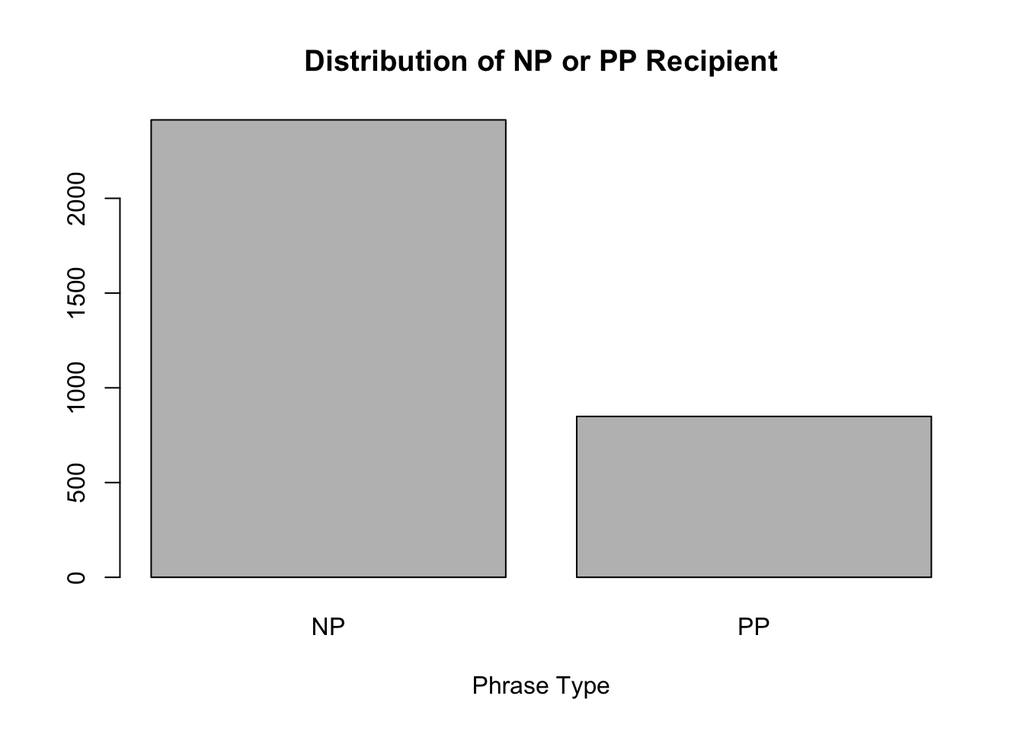

```r
barplot(table(dative$RealizationOfRecipient), main = "Distribution of NP or PP Recipient", xlab="Phrase Type")
```

There are a few ways we can examine how other linguistic factors impact the realization of an NP or PP recipient, such as comparing NP/PP realization versus modality, semantic class, length of recipient, animacy, definiteness, and accessibility (new vs. given vs. accessible referent). Prior to running statistical models, using **barplots**, **scatterplots**, **density plots**, and **boxplots** can be most useful for viewing how categorical outcomes are realized. Section III highlights considerations for when you create these plots.

### III. Categorical/Ordinal Data Plots

#### Barplots

Bar plots are best for representing **categorical and ordinal** data along the x-axis, and counts, percentages, or some other numeric value on the y-axis, such as in Figure 1.

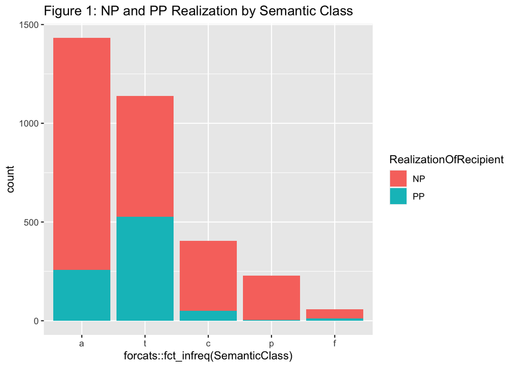

```r
# Figure 1 and Figure 2 with Flipped Axes Arrangements
ggplot(dative, aes(forcats::fct_infreq(SemanticClass), fill=RealizationOfRecipient))+
  geom_bar()+
  labs(title="Figure 1: NP and PP Realization by Semantic Class")
```

#### Boxplots & Violin Plots

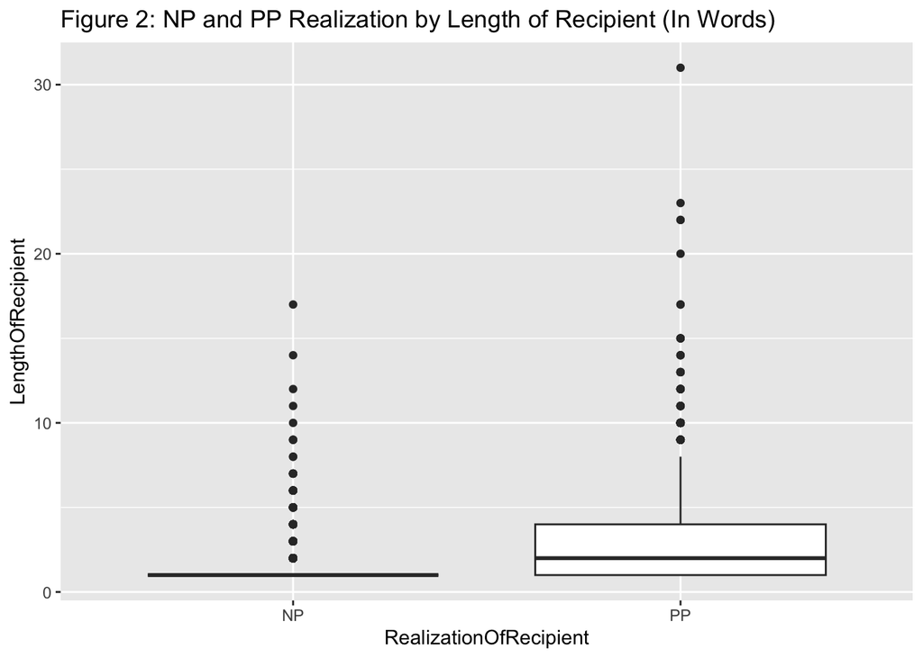

```r
ggplot(dative, aes(RealizationOfRecipient, LengthOfRecipient))+
  geom_boxplot()+
  labs(title="Figure 2: NP and PP Realization by Length of Recipient (In Words)")
```

We can also look at this same distribution using a violin plot. Wider portions of the violin plot indicate a greater distribution of tokens.

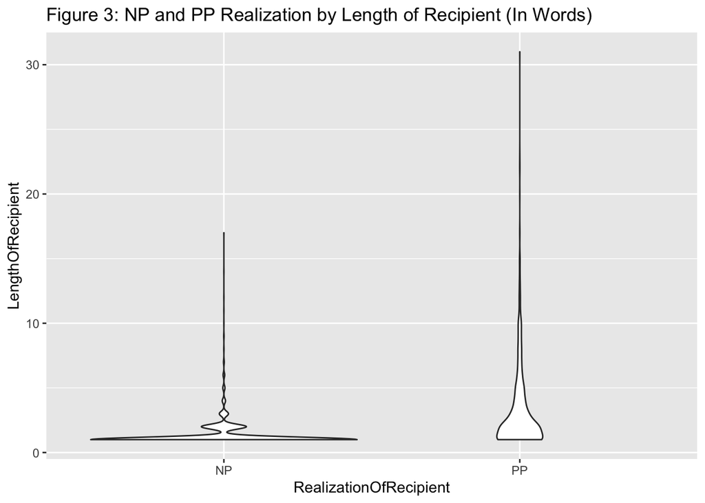

```r
ggplot(dative, aes(RealizationOfRecipient, LengthOfRecipient))+
  geom_violin()+
  labs(title="Figure 3: NP and PP Realization by Length of Recipient (In Words)")
```

#### Density Plots

Density plots measures the distribution of data via kernel density (a method of binning). It is used to approximate the probability density of a given variable. These are similar to histograms in that, in essence, they show distribution of your token count, but a bit more customizable and smooth, using ggplot:

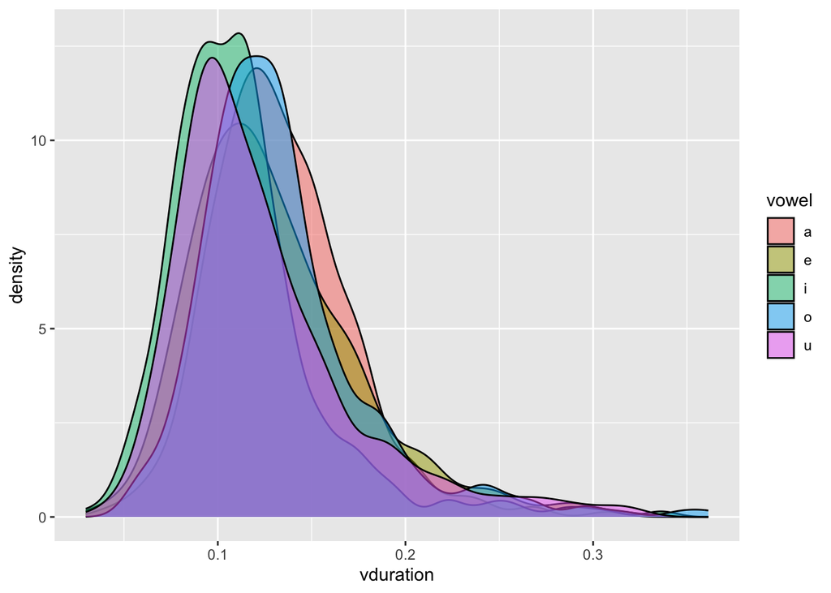

```r
vowels.raw <- read.csv("./vowels.csv")

ggplot(vowels.raw, aes(vduration, fill=vowel)) +
  geom_density(alpha = 0.5) +
  scale_color_brewer(palette="Set2")
```

#### Categorical scatterplots

Categorical scatterplots show the distribution of outcomes by individual data point. This offers a more detailed view of distributions of data, rather than condensing the distribution into a box or violin plot. In Figure 4, the realization of the Recipient as NP or PP is plotted against the Length of the Recipient (in words).

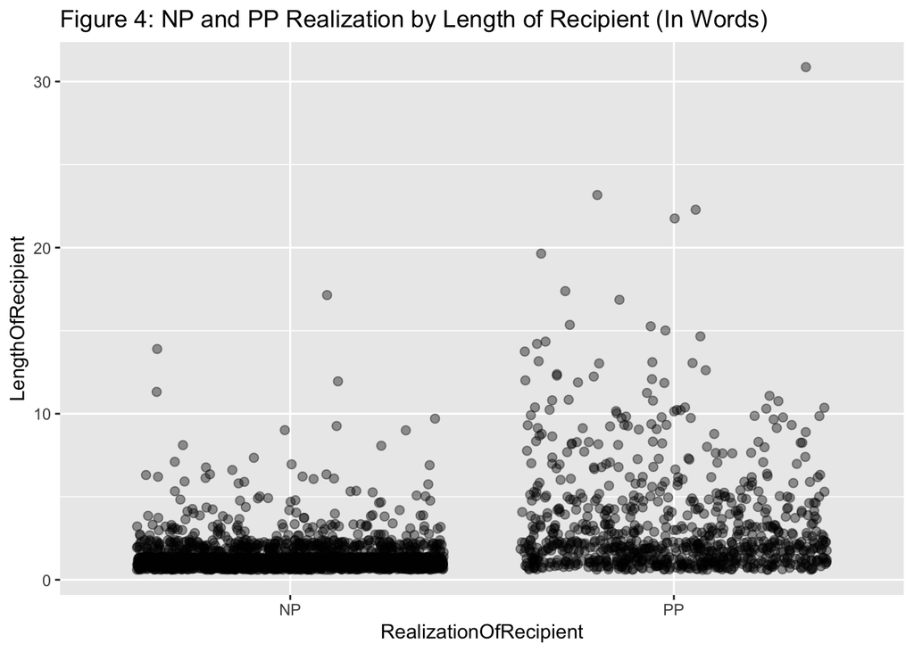

```r
ggplot(dative, aes(RealizationOfRecipient, LengthOfRecipient))+
  # size argument changes the point size; alpha argument changes transparency; position argument separates the points, rather than stacking them in a single line:
  geom_point(size=2, alpha=0.4, position="jitter")+
  labs(title="Figure 4: NP and PP Realization by Length of Recipient (In Words)")
```